# 금리 데이터 분석

## 1. 주제: 금리의 하락이 전세가 줄어드는 원인일까?

```python
import pandas as pd
import matplotlib.pyplot as plt


plt.rcParams.update({'font.family':'Malgun Gothic','font.size':12})
plt.rc('axes',unicode_minus=False)
```

## 2. 데이터 설명 및 탐색

### (1) 데이터 설명

- 데이터: 한국은행 경제통제시스템 제공 대출 금리 및 대출금
- 출처: 한국은행 경제통제시스템
  - 예금 금리 column(열)은 대출(개인대출, 기업대출, 신탁대출) 및 예수금(수시입출금, 정기예금, 정기적금), 산업금융채권, CD, RP 등 금융상품별 취급 금리이다.
- 데이터: 한국산업은행 제공 예금 금리 현황
- 출처: 공공데이터포털
- 데이터: KOSIS 제공 유형별 월세및 전세 가격지수, 전세가격 대비 월세 보증금 비율, 주택 유형 및 주거실태
- 출처: 한국보건사회연구원 (한국복지패널조사)

### (2) 파일 읽어오기

```python
import glob
glob.glob('Final data/예금금리 현황*.csv')
```

```
['Final data\\예금금리 현황1.csv',
 'Final data\\예금금리 현황2.csv',
 'Final data\\예금금리 현황3.csv',
 'Final data\\예금금리 현황4.csv']
```

```python
dfList = []
for fname in glob.glob('Final data/예금금리 현황*.csv'):
    temp = pd.read_csv(fname, encoding="cp949")
    dfList.append(temp)

df = pd.concat(dfList, ignore_index=True)
df.shape
```

```
(160, 41)
```

```python
df2 = pd.read_csv("Final data/대출금리.csv", encoding="cp949")
df3 = pd.read_csv("Final data/대출금.csv", encoding="cp949")
df4 = pd.read_csv("Final data/유형별 월세가격지수.csv", encoding="cp949")
df5 = pd.read_csv("Final data/유형별 전세가격지수.csv", encoding="cp949")
df6 = pd.read_csv("Final data/주택유형 및 주거실태.csv", encoding="cp949")
```

### (3) 데이터 탐색

#### 1~7번 데이터 파일 분석

```python
df.shape
```

```
(160, 41)
```

```python
df.head()
```

|  | 상품 | 기본금리 | 특별금리 | 기본우대이율A형(50만원~100만원) | 기본우대이율B형(100만원~300만원) | 기본우대이율C형(200만원~500만원) | 기본우대이율D형(500만원~2000만원) | 1천만원 미만 | 1천만원 이상 | 5천만원 이상 | ... | 30일 | 60일 | 91일 | 121일 | 181일 | 271일 | 기본우대이율A형 | 기본우대이율B형 | 기본우대이율C형 | 기본우대이율D형 |
| --- | --- | --- | --- | --- | --- | --- | --- | --- | --- | --- | --- | --- | --- | --- | --- | --- | --- | --- | --- | --- | --- |
| 0 | KDBdream Account* | 1.0 | NaN | NaN | NaN | NaN | NaN | NaN | NaN | NaN | ... | NaN | NaN | NaN | NaN | NaN | NaN | NaN | NaN | NaN | NaN |
| 1 | KDBdream자산관리 Account* | 0.2 | NaN | 0.45 | 0.5 | 0.8 | 1.0 | NaN | NaN | NaN | ... | NaN | NaN | NaN | NaN | NaN | NaN | NaN | NaN | NaN | NaN |
| 2 | KDBdream다모아 Account* | NaN | NaN | NaN | NaN | NaN | NaN | 0.2 | 0.3 | 0.6 | ... | NaN | NaN | NaN | NaN | NaN | NaN | NaN | NaN | NaN | NaN |
| 3 | 일 반정 기 적 금* | NaN | NaN | NaN | NaN | NaN | NaN | NaN | NaN | NaN | ... | NaN | NaN | NaN | NaN | NaN | NaN | NaN | NaN | NaN | NaN |
| 4 | 다모아 실세자 유 적 금* | NaN | NaN | NaN | NaN | NaN | NaN | NaN | NaN | NaN | ... | NaN | NaN | NaN | NaN | NaN | NaN | NaN | NaN | NaN | NaN |

5 rows × 41 columns

```python
df.tail()
```

|  | 상품 | 기본금리 | 특별금리 | 기본우대이율A형(50만원~100만원) | 기본우대이율B형(100만원~300만원) | 기본우대이율C형(200만원~500만원) | 기본우대이율D형(500만원~2000만원) | 1천만원 미만 | 1천만원 이상 | 5천만원 이상 | ... | 30일 | 60일 | 91일 | 121일 | 181일 | 271일 | 기본우대이율A형 | 기본우대이율B형 | 기본우대이율C형 | 기본우대이율D형 |
| --- | --- | --- | --- | --- | --- | --- | --- | --- | --- | --- | --- | --- | --- | --- | --- | --- | --- | --- | --- | --- | --- |
| 155 | KDBdream기업정기예금*_월이자지급식 | NaN | NaN | NaN | NaN | NaN | NaN | NaN | NaN | NaN | ... | NaN | NaN | NaN | NaN | NaN | NaN | NaN | NaN | NaN | NaN |
| 156 | KDBdream Jump-Up 정기예금*_해당월별 표면금리 | NaN | NaN | NaN | NaN | NaN | NaN | NaN | NaN | NaN | ... | NaN | NaN | NaN | NaN | NaN | NaN | NaN | NaN | NaN | NaN |
| 157 | KDBdream Jump-Up 정기예금*_만기지급식 연평균수익률 | NaN | NaN | NaN | NaN | NaN | NaN | NaN | NaN | NaN | ... | NaN | NaN | NaN | NaN | NaN | NaN | NaN | NaN | NaN | NaN |
| 158 | KDBdream Smart투자 정기예금*_연금지급식 | 1.04 | NaN | NaN | NaN | NaN | NaN | NaN | NaN | NaN | ... | NaN | NaN | NaN | NaN | NaN | NaN | NaN | NaN | NaN | NaN |
| 159 | KDBdream Smart투자 정기예금*_월이자지급식 | 1.03 | NaN | NaN | NaN | NaN | NaN | NaN | NaN | NaN | ... | NaN | NaN | NaN | NaN | NaN | NaN | NaN | NaN | NaN | NaN |

5 rows × 41 columns

```python
#예금 금리 현황
df.info(show_counts=True)
```

```
<class 'pandas.core.frame.DataFrame'>
RangeIndex: 160 entries, 0 to 159
Data columns (total 41 columns):
 #   Column                  Non-Null Count  Dtype
---  ------                  --------------  -----
 0   상품                      160 non-null    object
 1   기본금리                    28 non-null     float64
 2   특별금리                    4 non-null      float64
 3   기본우대이율A형(50만원~100만원)    3 non-null      float64
 4   기본우대이율B형(100만원~300만원)   3 non-null      float64
 5   기본우대이율C형(200만원~500만원)   3 non-null      float64
 6   기본우대이율D형(500만원~2000만원)  3 non-null      float64
 7   1천만원 미만                 8 non-null      float64
 8   1천만원 이상                 8 non-null      float64
 9   5천만원 이상                 8 non-null      float64
```

[output cut: 33 more lines]

### ※ Null값이 많이 보이므로 메모리 절약과 가독성을 위해 결측치 제거해야 함.

```python
#대출금리
df2.info(show_counts=True)
```

```
<class 'pandas.core.frame.DataFrame'>
RangeIndex: 15 entries, 0 to 14
Data columns (total 25 columns):
 #   Column  Non-Null Count  Dtype
---  ------  --------------  -----
 0   통계표     15 non-null     object
 1   항목명1    12 non-null     object
 2   단위      11 non-null     object
 3   변환      10 non-null     object
 4   2000    5 non-null      float64
 5   2001    5 non-null      float64
 6   2002    5 non-null      float64
 7   2003    6 non-null      float64
 8   2004    6 non-null      float64
 9   2005    6 non-null      float64
```

[output cut: 17 more lines]

```python
df2.tail()
```

|  | 통계표 | 항목명1 | 단위 | 변환 | 2000 | 2001 | 2002 | 2003 | 2004 | 2005 | ... | 2011 | 2012 | 2013 | 2014 | 2015 | 2016 | 2017 | 2018 | 2019 | 2020 |
| --- | --- | --- | --- | --- | --- | --- | --- | --- | --- | --- | --- | --- | --- | --- | --- | --- | --- | --- | --- | --- | --- |
| 10 | 4.1.2 시장금리(월 | 분기 | 년) | NaN | NaN | NaN | NaN | NaN | NaN | NaN | ... | NaN | NaN | NaN | NaN | NaN | NaN | NaN | NaN | NaN | NaN |
| 11 | 통계담당 : 한국은행 금융시장국 자금시장팀(02-759-4508) | 채권시장팀(02-759-5630) | NaN | NaN | NaN | NaN | NaN | NaN | NaN | NaN | ... | NaN | NaN | NaN | NaN | NaN | NaN | NaN | NaN | NaN | NaN |
| 12 | 주 : 1) 월평균(영업일기준) | NaN | NaN | NaN | NaN | NaN | NaN | NaN | NaN | NaN | ... | NaN | NaN | NaN | NaN | NaN | NaN | NaN | NaN | NaN | NaN |
| 13 | 2) 국고채(30년) : 2012.9월부터 발행 | NaN | NaN | NaN | NaN | NaN | NaN | NaN | NaN | NaN | ... | NaN | NaN | NaN | NaN | NaN | NaN | NaN | NaN | NaN | NaN |
| 14 | 3) 통안증권(1년) : 2011.5.1부터 364일물(할인채)에서 1년물(이표채)... | NaN | NaN | NaN | NaN | NaN | NaN | NaN | NaN | NaN | ... | NaN | NaN | NaN | NaN | NaN | NaN | NaN | NaN | NaN | NaN |

5 rows × 25 columns

### ※맨 아래쪽에 index들은 데이터에 대한 설명들로 불필요한 index를 삭제해서 결측 데이터를 제거하자.

```python
#대출금
df3.info(show_counts=True)
```

```
<class 'pandas.core.frame.DataFrame'>
RangeIndex: 26 entries, 0 to 25
Data columns (total 19 columns):
 #   Column  Non-Null Count  Dtype
---  ------  --------------  -----
 0   통계표     26 non-null     object
 1   항목명1    19 non-null     object
 2   항목명2    18 non-null     object
 3   단위      18 non-null     object
 4   변환      18 non-null     object
 5   2007    17 non-null     object
 6   2008    17 non-null     object
 7   2009    17 non-null     object
 8   2010    17 non-null     object
 9   2011    17 non-null     object
 10  2012    18 non-null     object
 11  2013    18 non-null     object
 12  2014    18 non-null     object
 13  2015    18 non-null     object
 14  2016    18 non-null     object
 15  2017    18 non-null     object
 16  2018    18 non-null     object
 17  2019    18 non-null     object
 18  2020    18 non-null     object
dtypes: object(19)
memory usage: 4.0+ KB
```

```python
#대출금
df3.tail()
```

|  | 통계표 | 항목명1 | 항목명2 | 단위 | 변환 | 2007 | 2008 | 2009 | 2010 | 2011 | 2012 | 2013 | 2014 | 2015 | 2016 | 2017 | 2018 | 2019 | 2020 |
| --- | --- | --- | --- | --- | --- | --- | --- | --- | --- | --- | --- | --- | --- | --- | --- | --- | --- | --- | --- |
| 21 | 2) 농협 및 수협중앙회의 회원조합을 통한 정책자금 대출금 포함\t\t\t\t | NaN | NaN | NaN | NaN | NaN | NaN | NaN | NaN | NaN | NaN | NaN | NaN | NaN | NaN | NaN | NaN | NaN | NaN |
| 22 | 3) 제10차 한국표준산업분류(2017. 7. 1. 시행)에 따라 개정된 산업분류에... | NaN | NaN | NaN | NaN | NaN | NaN | NaN | NaN | NaN | NaN | NaN | NaN | NaN | NaN | NaN | NaN | NaN | NaN |
| 23 | 5) 시.도별 구분은 취급점포 소재지 기준임 | NaN | NaN | NaN | NaN | NaN | NaN | NaN | NaN | NaN | NaN | NaN | NaN | NaN | NaN | NaN | NaN | NaN | NaN |
| 24 | 6) 2012년 3/4분기부터 세종시 통계가 추가됨에 따라 그동안 충남(연기군전체 | 공주시 일부) 및 충북(청원군 일부)지역에 | NaN | NaN | NaN | NaN | NaN | NaN | NaN | NaN | NaN | NaN | NaN | NaN | NaN | NaN | NaN | NaN | NaN |
| 25 | 포함되었던 지역통계가 세종시로 이관됨에 따라 충남 및 충북통계 이용시 201... | NaN | NaN | NaN | NaN | NaN | NaN | NaN | NaN | NaN | NaN | NaN | NaN | NaN | NaN | NaN | NaN | NaN | NaN |

### ※맨 아래쪽에 index들은 데이터에 대한 설명들로 불필요한 index를 삭제해서 결측 데이터를 제거하자.

```python
#유형별 월세가격지수
df4.info(show_counts=True)
```

```
<class 'pandas.core.frame.DataFrame'>
RangeIndex: 28 entries, 0 to 27
Data columns (total 79 columns):
 #   Column    Non-Null Count  Dtype
---  ------    --------------  -----
 0   주택유형별(1)  28 non-null     object
 1   지역별(1)    28 non-null     object
 2   2015. 06  28 non-null     float64
 3   2015. 07  28 non-null     float64
 4   2015. 08  28 non-null     float64
 5   2015. 09  28 non-null     float64
 6   2015. 10  28 non-null     float64
 7   2015. 11  28 non-null     float64
 8   2015. 12  28 non-null     float64
 9   2016. 01  28 non-null     float64
```

[output cut: 71 more lines]

```python
df4.tail()
```

|  | 주택유형별(1) | 지역별(1) | 2015. 06 | 2015. 07 | 2015. 08 | 2015. 09 | 2015. 10 | 2015. 11 | 2015. 12 | 2016. 01 | ... | 2021. 01 | 2021. 02 | 2021. 03 | 2021. 04 | 2021. 05 | 2021. 06 | 2021. 07 | 2021. 08 | 2021. 09 | 2021. 10 |
| --- | --- | --- | --- | --- | --- | --- | --- | --- | --- | --- | --- | --- | --- | --- | --- | --- | --- | --- | --- | --- | --- |
| 23 | 단독주택 | 지방 | 101.6 | 101.7 | 101.7 | 101.7 | 101.7 | 101.7 | 101.7 | 101.7 | ... | 100.0 | 100.0 | 100.0 | 100.0 | 100.0 | 100.0 | 100.0 | 100.1 | 100.1 | 100.1 |
| 24 | 단독주택 | 6대광역시 | 101.9 | 101.9 | 101.9 | 101.9 | 101.9 | 101.8 | 101.8 | 101.8 | ... | 99.9 | 100.0 | 100.0 | 100.0 | 100.0 | 100.0 | 100.1 | 100.1 | 100.2 | 100.2 |
| 25 | 단독주택 | 5대광역시 | 102.0 | 102.1 | 102.1 | 102.0 | 102.1 | 102.0 | 102.0 | 102.0 | ... | 100.0 | 100.0 | 100.0 | 100.0 | 100.0 | 100.0 | 100.0 | 100.1 | 100.2 | 100.2 |
| 26 | 단독주택 | 9개도 | 101.3 | 101.4 | 101.4 | 101.3 | 101.3 | 101.4 | 101.3 | 101.3 | ... | 100.0 | 100.0 | 100.0 | 100.0 | 100.0 | 100.0 | 100.0 | 100.1 | 100.1 | 100.2 |
| 27 | 단독주택 | 8개도 | 101.5 | 101.6 | 101.6 | 101.6 | 101.6 | 101.6 | 101.6 | 101.6 | ... | 100.0 | 100.0 | 100.0 | 100.0 | 100.0 | 100.0 | 100.0 | 100.0 | 100.1 | 100.1 |

5 rows × 79 columns

```python
#유형별 전세가격지수
df5.info(show_counts=True)
```

```
<class 'pandas.core.frame.DataFrame'>
RangeIndex: 28 entries, 0 to 27
Columns: 181 entries, 주택유형별(1) to 2021. 10
dtypes: float64(179), object(2)
memory usage: 39.7+ KB
```

```python
df5.tail()
```

|  | 주택유형별(1) | 지역별(1) | 2006. 12 | 2007. 01 | 2007. 02 | 2007. 03 | 2007. 04 | 2007. 05 | 2007. 06 | 2007. 07 | ... | 2021. 01 | 2021. 02 | 2021. 03 | 2021. 04 | 2021. 05 | 2021. 06 | 2021. 07 | 2021. 08 | 2021. 09 | 2021. 10 |
| --- | --- | --- | --- | --- | --- | --- | --- | --- | --- | --- | --- | --- | --- | --- | --- | --- | --- | --- | --- | --- | --- |
| 23 | 단독주택 | 지방 | 88.3 | 88.2 | 88.2 | 88.3 | 88.3 | 88.3 | 88.3 | 88.4 | ... | 99.8 | 99.8 | 99.9 | 99.9 | 100.0 | 100.0 | 100.1 | 100.2 | 100.3 | 100.3 |
| 24 | 단독주택 | 6대광역시 | 88.1 | 88.2 | 88.2 | 88.4 | 88.5 | 88.8 | 88.7 | 88.7 | ... | 99.8 | 99.8 | 99.8 | 99.9 | 99.9 | 100.0 | 100.1 | 100.2 | 100.4 | 100.5 |
| 25 | 단독주택 | 5대광역시 | 89.8 | 89.8 | 89.8 | 90.0 | 90.1 | 90.2 | 90.1 | 90.1 | ... | 99.8 | 99.8 | 99.9 | 99.9 | 99.9 | 100.0 | 100.1 | 100.2 | 100.4 | 100.5 |
| 26 | 단독주택 | 9개도 | 86.2 | 86.3 | 86.3 | 86.4 | 86.5 | 86.5 | 86.6 | 86.7 | ... | 99.8 | 99.8 | 99.9 | 99.9 | 100.0 | 100.0 | 100.1 | 100.2 | 100.3 | 100.4 |
| 27 | 단독주택 | 8개도 | 87.9 | 87.8 | 87.8 | 87.9 | 87.8 | 87.8 | 87.9 | 88.0 | ... | 99.8 | 99.8 | 99.9 | 99.9 | 100.0 | 100.0 | 100.1 | 100.1 | 100.2 | 100.3 |

5 rows × 181 columns

```python
#주택유형 및 주거실태
df6.info(show_counts=True)
```

[output not shown]

[output cut: 70 more lines]

```python
df6.tail()
```

[output not shown]

5 rows × 78 columns

## 3. 데이터 전처리 및 데이터 가공

### (1) 불필요한 열 제거

```python
# 대출금리 파일 불필요한 index제거
df2
```

|  | 통계표 | 항목명1 | 단위 | 변환 | 2000 | 2001 | 2002 | 2003 | 2004 | 2005 | ... | 2011 | 2012 | 2013 | 2014 | 2015 | 2016 | 2017 | 2018 | 2019 | 2020 |
| --- | --- | --- | --- | --- | --- | --- | --- | --- | --- | --- | --- | --- | --- | --- | --- | --- | --- | --- | --- | --- | --- |
| 0 | 4.1.2 시장금리(월,분기,년) | 무담보콜금리 전체 | 연% | 원자료 | 5.16 | 4.69 | 4.21 | 4.00 | 3.65 | 3.33 | ... | 3.09 | 3.08 | 2.59 | 2.340 | 1.650 | 1.340 | 1.260 | 1.520 | 1.590 | 0.700 |
| 1 | 4.1.2 시장금리(월,분기,년) | 담보콜금리전체 | 연% | 원자료 | NaN | NaN | NaN | 4.00 | 3.66 | 3.40 | ... | 3.23 | 3.18 | 2.68 | 2.530 | NaN | NaN | NaN | NaN | NaN | NaN |
| 2 | 4.1.2 시장금리(월,분기,년) | KORIBOR(12M) | 연% | 원자료 | NaN | NaN | NaN | NaN | NaN | NaN | ... | 3.71 | 3.35 | 2.78 | 2.520 | 1.760 | 1.510 | 1.680 | 2.010 | 1.690 | 1.030 |
| 3 | 4.1.2 시장금리(월,분기,년) | CP유통수익률(91일) | 연% | 원자료 | 7.44 | 5.60 | 4.93 | 4.62 | 3.97 | 3.81 | ... | 3.59 | 3.39 | 2.81 | 2.600 | 1.860 | 1.620 | 1.640 | 1.830 | 1.840 | 1.500 |
| 4 | 4.1.2 시장금리(월,분기,년) | 국민주택채권1종(5년) | 연% | 원자료 | 8.50 | 6.66 | 6.47 | 4.93 | 4.45 | 4.66 | ... | 4.11 | 3.43 | 3.16 | 2.977 | 2.106 | 1.661 | 2.164 | 2.454 | 1.675 | 1.371 |
| 5 | 4.1.2 시장금리(월,분기,년) | 국고채(20년) | 연% | 원자료 | NaN | NaN | NaN | NaN | NaN | NaN | ... | 4.34 | 3.53 | 3.46 | 3.375 | 2.478 | 1.821 | 2.333 | 2.477 | 1.711 | 1.610 |
| 6 | 4.1.2 시장금리(월,분기,년) | 산금채(1년) | 연% | 원자료 | 7.92 | 5.55 | 5.29 | 4.53 | 3.98 | 4.06 | ... | 3.65 | 3.23 | 2.72 | 2.488 | 1.765 | 1.493 | 1.637 | 1.976 | 1.638 | 0.973 |
| 7 | 4.1.2 시장금리(월,분기,년) | 회사채(장외3년,AA- 등급) | 연% | 원자료 | 9.35 | 7.05 | 6.56 | 5.43 | 4.73 | 4.68 | ... | 4.41 | 3.77 | 3.19 | 2.983 | 2.084 | 1.886 | 2.325 | 2.651 | 2.023 | 2.128 |
| 8 | 4.1.2 시장금리(월,분기,년) | MMF(7일) | 연% | 원자료 | NaN | NaN | NaN | NaN | NaN | NaN | ... | NaN | NaN | NaN | 2.420 | 1.670 | 1.350 | 1.310 | 1.630 | 1.660 | 0.960 |
| 9 | 4.1.2 시장금리(월,분기,년) | CMA(수시형) | 연% | 원자료 | NaN | NaN | NaN | NaN | NaN | NaN | ... | NaN | NaN | NaN | 2.260 | 1.540 | 1.230 | 1.130 | 1.240 | 1.290 | 0.430 |
| 10 | 4.1.2 시장금리(월 | 분기 | 년) | NaN | NaN | NaN | NaN | NaN | NaN | NaN | ... | NaN | NaN | NaN | NaN | NaN | NaN | NaN | NaN | NaN | NaN |
| 11 | 통계담당 : 한국은행 금융시장국 자금시장팀(02-759-4508) | 채권시장팀(02-759-5630) | NaN | NaN | NaN | NaN | NaN | NaN | NaN | NaN | ... | NaN | NaN | NaN | NaN | NaN | NaN | NaN | NaN | NaN | NaN |
| 12 | 주 : 1) 월평균(영업일기준) | NaN | NaN | NaN | NaN | NaN | NaN | NaN | NaN | NaN | ... | NaN | NaN | NaN | NaN | NaN | NaN | NaN | NaN | NaN | NaN |
| 13 | 2) 국고채(30년) : 2012.9월부터 발행 | NaN | NaN | NaN | NaN | NaN | NaN | NaN | NaN | NaN | ... | NaN | NaN | NaN | NaN | NaN | NaN | NaN | NaN | NaN | NaN |
| 14 | 3) 통안증권(1년) : 2011.5.1부터 364일물(할인채)에서 1년물(이표채)... | NaN | NaN | NaN | NaN | NaN | NaN | NaN | NaN | NaN | ... | NaN | NaN | NaN | NaN | NaN | NaN | NaN | NaN | NaN | NaN |

15 rows × 25 columns

### ※ index 10번은 오류 데이터이고 11번부터 14번은 불필요한 데이터이므로 제거 또한 '통계표' 행도 모든 행이 똑같은므로 제거

```python
df2.drop(index=[10,11,12,13,14], inplace=True)
df2.drop('통계표',axis=1, inplace=True)
```

```python
#제거되었는지 확인
df2
```

|  | 항목명1 | 단위 | 변환 | 2000 | 2001 | 2002 | 2003 | 2004 | 2005 | 2006 | ... | 2011 | 2012 | 2013 | 2014 | 2015 | 2016 | 2017 | 2018 | 2019 | 2020 |
| --- | --- | --- | --- | --- | --- | --- | --- | --- | --- | --- | --- | --- | --- | --- | --- | --- | --- | --- | --- | --- | --- |
| 0 | 무담보콜금리 전체 | 연% | 원자료 | 5.16 | 4.69 | 4.21 | 4.00 | 3.65 | 3.33 | 4.19 | ... | 3.09 | 3.08 | 2.59 | 2.340 | 1.650 | 1.340 | 1.260 | 1.520 | 1.590 | 0.700 |
| 1 | 담보콜금리전체 | 연% | 원자료 | NaN | NaN | NaN | 4.00 | 3.66 | 3.40 | 4.30 | ... | 3.23 | 3.18 | 2.68 | 2.530 | NaN | NaN | NaN | NaN | NaN | NaN |
| 2 | KORIBOR(12M) | 연% | 원자료 | NaN | NaN | NaN | NaN | NaN | NaN | NaN | ... | 3.71 | 3.35 | 2.78 | 2.520 | 1.760 | 1.510 | 1.680 | 2.010 | 1.690 | 1.030 |
| 3 | CP유통수익률(91일) | 연% | 원자료 | 7.44 | 5.60 | 4.93 | 4.62 | 3.97 | 3.81 | 4.65 | ... | 3.59 | 3.39 | 2.81 | 2.600 | 1.860 | 1.620 | 1.640 | 1.830 | 1.840 | 1.500 |
| 4 | 국민주택채권1종(5년) | 연% | 원자료 | 8.50 | 6.66 | 6.47 | 4.93 | 4.45 | 4.66 | 5.07 | ... | 4.11 | 3.43 | 3.16 | 2.977 | 2.106 | 1.661 | 2.164 | 2.454 | 1.675 | 1.371 |
| 5 | 국고채(20년) | 연% | 원자료 | NaN | NaN | NaN | NaN | NaN | NaN | 5.37 | ... | 4.34 | 3.53 | 3.46 | 3.375 | 2.478 | 1.821 | 2.333 | 2.477 | 1.711 | 1.610 |
| 6 | 산금채(1년) | 연% | 원자료 | 7.92 | 5.55 | 5.29 | 4.53 | 3.98 | 4.06 | 4.75 | ... | 3.65 | 3.23 | 2.72 | 2.488 | 1.765 | 1.493 | 1.637 | 1.976 | 1.638 | 0.973 |
| 7 | 회사채(장외3년,AA- 등급) | 연% | 원자료 | 9.35 | 7.05 | 6.56 | 5.43 | 4.73 | 4.68 | 5.17 | ... | 4.41 | 3.77 | 3.19 | 2.983 | 2.084 | 1.886 | 2.325 | 2.651 | 2.023 | 2.128 |
| 8 | MMF(7일) | 연% | 원자료 | NaN | NaN | NaN | NaN | NaN | NaN | NaN | ... | NaN | NaN | NaN | 2.420 | 1.670 | 1.350 | 1.310 | 1.630 | 1.660 | 0.960 |
| 9 | CMA(수시형) | 연% | 원자료 | NaN | NaN | NaN | NaN | NaN | NaN | NaN | ... | NaN | NaN | NaN | 2.260 | 1.540 | 1.230 | 1.130 | 1.240 | 1.290 | 0.430 |

10 rows × 24 columns

```python
# 대출금 파일 불필요한 index제거
df3
```

|  | 통계표 | 항목명1 | 항목명2 | 단위 | 변환 | 2007 | 2008 | 2009 | 2010 | 2011 | 2012 | 2013 | 2014 | 2015 | 2016 | 2017 | 2018 | 2019 | 2020 |
| --- | --- | --- | --- | --- | --- | --- | --- | --- | --- | --- | --- | --- | --- | --- | --- | --- | --- | --- | --- |
| 0 | 3.3.3.1 총대출금(지역별) | 대출금 총계 | 전국 | 십억원 | 원자료 | 803,724.1 | 917,110.1 | 953,505.2 | 987,148.1 | 1,063,192.5 | 1,099,781.8 | 1,154,760.3 | 1,250,103.3 | 1,346,815.8 | 1,424,149.2 | 1,504,333.3 | 1,600,280.5 | 1,698,612.9 | 1,893,716.2 |
| 1 | 3.3.3.1 총대출금(지역별) | 대출금 총계 | 서울 | 십억원 | 원자료 | 343,163.0 | 406,595.6 | 413,183.9 | 423,631.2 | 455,160.8 | 453,586.6 | 462,443.1 | 494,441.9 | 525,529.1 | 544,592.1 | 569,688.0 | 607,389.3 | 641,634.1 | 726,164.1 |
| 2 | 3.3.3.1 총대출금(지역별) | 대출금 총계 | 부산 | 십억원 | 원자료 | 51,078.3 | 55,776.8 | 56,980.8 | 59,708.7 | 66,473.8 | 71,707.9 | 77,411.6 | 84,345.8 | 92,109.5 | 99,122.7 | 106,819.1 | 113,616.7 | 120,127.2 | 132,190.6 |
| 3 | 3.3.3.1 총대출금(지역별) | 대출금 총계 | 대구 | 십억원 | 원자료 | 33,539.5 | 35,402.0 | 36,858.4 | 37,568.3 | 40,073.7 | 42,708.2 | 46,578.5 | 53,214.0 | 61,642.8 | 66,966.8 | 71,095.8 | 74,462.0 | 80,062.2 | 88,740.3 |
| 4 | 3.3.3.1 총대출금(지역별) | 대출금 총계 | 인천 | 십억원 | 원자료 | 39,470.3 | 44,102.2 | 48,812.9 | 52,574.1 | 57,408.1 | 60,034.3 | 62,378.2 | 66,365.0 | 69,059.0 | 73,804.8 | 80,147.3 | 85,660.7 | 92,157.9 | 102,078.4 |
| 5 | 3.3.3.1 총대출금(지역별) | 대출금 총계 | 광주 | 십억원 | 원자료 | 17,921.5 | 19,197.4 | 18,579.0 | 18,094.0 | 19,466.4 | 20,823.9 | 23,082.8 | 24,782.2 | 28,259.6 | 30,354.2 | 31,038.5 | 33,475.5 | 36,888.6 | 42,161.3 |
| 6 | 3.3.3.1 총대출금(지역별) | 대출금 총계 | 대전 | 십억원 | 원자료 | 16,605.0 | 17,428.2 | 17,884.9 | 18,593.2 | 20,616.0 | 21,968.0 | 23,859.8 | 25,804.7 | 27,830.0 | 29,590.8 | 31,050.7 | 33,252.0 | 35,318.1 | 39,341.3 |
| 7 | 3.3.3.1 총대출금(지역별) | 대출금 총계 | 울산 | 십억원 | 원자료 | 12,359.5 | 14,241.8 | 14,625.2 | 14,958.0 | 16,475.5 | 17,898.3 | 19,560.1 | 21,981.2 | 24,057.9 | 25,364.2 | 26,949.2 | 27,620.7 | 28,495.1 | 30,498.2 |
| 8 | 3.3.3.1 총대출금(지역별) | 대출금 총계 | 경기 | 십억원 | 원자료 | 166,386.9 | 187,560.1 | 205,433.7 | 216,001.6 | 229,840.4 | 237,118.4 | 248,468.3 | 268,494.6 | 284,496.7 | 305,720.4 | 326,152.3 | 350,553.6 | 376,464.3 | 419,831.8 |
| 9 | 3.3.3.1 총대출금(지역별) | 대출금 총계 | 강원 | 십억원 | 원자료 | 10,233.0 | 10,626.8 | 10,687.6 | 10,990.6 | 11,458.4 | 12,144.3 | 13,259.9 | 14,184.7 | 15,464.9 | 16,415.4 | 17,587.6 | 19,200.5 | 20,991.4 | 22,831.4 |
| 10 | 3.3.3.1 총대출금(지역별) | 대출금 총계 | 충북 | 십억원 | 원자료 | 11,423.4 | 12,898.3 | 13,506.1 | 13,527.4 | 14,453.6 | 15,672.7 | 17,211.7 | 19,076.8 | 21,044.6 | 22,070.0 | 23,178.8 | 25,028.7 | 26,399.9 | 28,669.1 |
| 11 | 3.3.3.1 총대출금(지역별) | 대출금 총계 | 충남 | 십억원 | 원자료 | 17,808.5 | 20,593.4 | 22,037.4 | 22,874.5 | 24,258.0 | 24,703.4 | 26,445.4 | 29,451.1 | 32,255.0 | 33,828.8 | 35,278.9 | 36,232.6 | 37,360.9 | 41,097.0 |
| 12 | 3.3.3.1 총대출금(지역별) | 대출금 총계 | 전북 | 십억원 | 원자료 | 14,686.8 | 15,711.0 | 16,114.7 | 16,856.9 | 18,543.1 | 20,491.5 | 22,597.6 | 24,625.9 | 26,242.4 | 27,330.1 | 28,323.0 | 29,107.6 | 30,488.3 | 33,132.0 |
| 13 | 3.3.3.1 총대출금(지역별) | 대출금 총계 | 전남 | 십억원 | 원자료 | 11,037.6 | 11,945.1 | 12,196.3 | 12,389.3 | 13,309.3 | 14,944.8 | 15,968.2 | 17,164.0 | 19,216.7 | 20,060.0 | 21,010.3 | 22,228.8 | 23,785.6 | 26,806.6 |
| 14 | 3.3.3.1 총대출금(지역별) | 대출금 총계 | 경북 | 십억원 | 원자료 | 18,249.9 | 20,224.1 | 20,930.7 | 21,866.3 | 23,713.8 | 25,858.0 | 28,452.3 | 31,642.7 | 35,582.2 | 37,300.0 | 39,225.6 | 40,939.9 | 43,118.9 | 47,189.5 |
| 15 | 3.3.3.1 총대출금(지역별) | 대출금 총계 | 경남 | 십억원 | 원자료 | 34,352.8 | 39,099.5 | 39,841.1 | 41,711.3 | 45,940.5 | 52,023.0 | 57,288.6 | 62,681.3 | 68,619.5 | 72,333.0 | 74,494.8 | 76,526.6 | 78,235.3 | 82,937.6 |
| 16 | 3.3.3.1 총대출금(지역별) | 대출금 총계 | 제주 | 십억원 | 원자료 | 5,408.1 | 5,707.7 | 5,832.6 | 5,802.7 | 6,001.2 | 6,512.2 | 7,325.0 | 8,312.3 | 10,191.0 | 12,548.2 | 14,707.9 | 16,633.8 | 18,281.1 | 20,182.3 |
| 17 | 3.3.3.1 총대출금(지역별) | 대출금 총계 | 세종 | 십억원 | 원자료 | NaN | NaN | NaN | NaN | NaN | 1,586.3 | 2,429.1 | 3,535.0 | 5,215.0 | 6,747.6 | 7,585.8 | 8,351.6 | 8,803.9 | 9,864.7 |
| 18 | 3.3.3.1 총대출금(지역별) | NaN | NaN | NaN | NaN | NaN | NaN | NaN | NaN | NaN | NaN | NaN | NaN | NaN | NaN | NaN | NaN | NaN | NaN |
| 19 | 통계담당 : 한국은행 경제통계국 금융통계팀(02-759-4436) | NaN | NaN | NaN | NaN | NaN | NaN | NaN | NaN | NaN | NaN | NaN | NaN | NaN | NaN | NaN | NaN | NaN | NaN |
| 20 | 주 : 1) 농협중앙회의 타은행을 통한 지자체협약대출금 중 일부 포함\t\t\t\t | NaN | NaN | NaN | NaN | NaN | NaN | NaN | NaN | NaN | NaN | NaN | NaN | NaN | NaN | NaN | NaN | NaN | NaN |
| 21 | 2) 농협 및 수협중앙회의 회원조합을 통한 정책자금 대출금 포함\t\t\t\t | NaN | NaN | NaN | NaN | NaN | NaN | NaN | NaN | NaN | NaN | NaN | NaN | NaN | NaN | NaN | NaN | NaN | NaN |
| 22 | 3) 제10차 한국표준산업분류(2017. 7. 1. 시행)에 따라 개정된 산업분류에... | NaN | NaN | NaN | NaN | NaN | NaN | NaN | NaN | NaN | NaN | NaN | NaN | NaN | NaN | NaN | NaN | NaN | NaN |
| 23 | 5) 시.도별 구분은 취급점포 소재지 기준임 | NaN | NaN | NaN | NaN | NaN | NaN | NaN | NaN | NaN | NaN | NaN | NaN | NaN | NaN | NaN | NaN | NaN | NaN |
| 24 | 6) 2012년 3/4분기부터 세종시 통계가 추가됨에 따라 그동안 충남(연기군전체 | 공주시 일부) 및 충북(청원군 일부)지역에 | NaN | NaN | NaN | NaN | NaN | NaN | NaN | NaN | NaN | NaN | NaN | NaN | NaN | NaN | NaN | NaN | NaN |
| 25 | 포함되었던 지역통계가 세종시로 이관됨에 따라 충남 및 충북통계 이용시 201... | NaN | NaN | NaN | NaN | NaN | NaN | NaN | NaN | NaN | NaN | NaN | NaN | NaN | NaN | NaN | NaN | NaN | NaN |

### ※ index 18번은 오류 데이터이고 19번부터 25번은 불필요한 데이터이므로 제거

```python
df3.drop(index=[18,19,20,21,22,23,24,25], inplace=True)
```

```python
#제거되었는지 확인
df3.index
```

```
Int64Index([0, 1, 2, 3, 4, 5, 6, 7, 8, 9, 10, 11, 12, 13, 14, 15, 16, 17], dtype='int64')
```

```python
# 주택유형 및 주거실태파일 불필요한 데이터 제거
df6
```

|  | 실태별(1) | 실태별(2) | 2012 | 2012.1 | 2012.2 | 2013 | 2013.1 | 2013.2 | 2014 | 2014.1 | ... | 2016.2 | 2017 | 2017.1 | 2017.2 | 2018 | 2018.1 | 2018.2 | 2019 | 2019.1 | 2019.2 |
| --- | --- | --- | --- | --- | --- | --- | --- | --- | --- | --- | --- | --- | --- | --- | --- | --- | --- | --- | --- | --- | --- |
| 0 | 실태별(1) | 실태별(2) | 전체 | 저소득 | 일반 | 전체 | 저소득 | 일반 | 전체 | 저소득 | ... | 일반 | 전체 | 저소득 | 일반 | 전체 | 저소득 | 일반 | 전체 | 저소득 | 일반 |
| 1 | 주거점유형태별 | 자가 | 53.15 | 41.36 | 57.76 | 54.06 | 43.58 | 58.26 | 54.75 | 43.37 | ... | 60.66 | 56.12 | 45.02 | 60.14 | 56.00 | 45.33 | 59.78 | 56.33 | 46.04 | 60.01 |
| 2 | 주거점유형태별 | 전세 | 17.56 | 13.74 | 19.00 | 16.48 | 13.12 | 17.82 | 15.50 | 10.16 | ... | 14.81 | 13.38 | 9.63 | 14.74 | 13.57 | 8.94 | 15.21 | 14.93 | 9.99 | 16.69 |
| 3 | 주거점유형태별 | 보증부 월세 | 18.78 | 24.83 | 16.41 | 18.75 | 24.38 | 16.49 | 18.70 | 26.35 | ... | 17.50 | 19.93 | 26.35 | 17.60 | 20.24 | 27.20 | 17.79 | 19.53 | 27.35 | 16.74 |
| 4 | 주거점유형태별 | 월세 | 1.78 | 3.77 | 1.00 | 1.98 | 3.64 | 1.31 | 2.29 | 3.88 | ... | 0.97 | 1.81 | 3.38 | 1.24 | 1.52 | 3.06 | 0.98 | 1.21 | 2.12 | 0.88 |
| 5 | 주거점유형태별 | 비가구원 명의 주택 | - | - | - | - | - | - | - | - | ... | - | - | - | - | 6.74 | 13.93 | 4.20 | 6.14 | 12.45 | 3.89 |
| 6 | 주거점유형태별 | 기타 | 8.74 | 16.31 | 5.77 | 8.74 | 15.28 | 6.11 | 8.76 | 16.23 | ... | 6.05 | 8.76 | 15.61 | 6.27 | 1.91 | 1.54 | 2.05 | 1.86 | 2.05 | 1.79 |

7 rows × 26 columns

### ※ 전체를 제외한 저소득과 일반열은 불필요한 데이터이다.

```python
df6.drop(['2012.1','2012.2','2013.1','2013.2','2014.1','2014.2','2015.1','2015.2','2016.1','2016.2','2017.1','2017.2','2018.1','2018.2','2019.1','2019.2'],axis=1,inplace=True)
```

```python
#제거되었는지 확인
df6.columns
```

```
Index(['실태별(1)', '실태별(2)', '2012', '2013', '2014', '2015', '2016', '2017',
       '2018', '2019'],
      dtype='object')
```

### (2) 예금 금리 현황 합친 데이터 가공

◈ 합쳐진 데이터 확인

```python
df
```

[output not shown]

160 rows × 41 columns

### ※ 예금 금리는 연도별로 파일이 1~4로 나눠져 있었다. RangeIndex대신 연도를 입력하여 데이터를 분류하자.

```python
df.loc[:39]
```

|  | 상품 | 기본금리 | 특별금리 | 기본우대이율A형(50만원~100만원) | 기본우대이율B형(100만원~300만원) | 기본우대이율C형(200만원~500만원) | 기본우대이율D형(500만원~2000만원) | 1천만원 미만 | 1천만원 이상 | 5천만원 이상 | ... | 30일 | 60일 | 91일 | 121일 | 181일 | 271일 | 기본우대이율A형 | 기본우대이율B형 | 기본우대이율C형 | 기본우대이율D형 |
| --- | --- | --- | --- | --- | --- | --- | --- | --- | --- | --- | --- | --- | --- | --- | --- | --- | --- | --- | --- | --- | --- |
| 0 | KDBdream Account* | 1.00 | NaN | NaN | NaN | NaN | NaN | NaN | NaN | NaN | ... | NaN | NaN | NaN | NaN | NaN | NaN | NaN | NaN | NaN | NaN |
| 1 | KDBdream자산관리 Account* | 0.20 | NaN | 0.45 | 0.5 | 0.8 | 1.0 | NaN | NaN | NaN | ... | NaN | NaN | NaN | NaN | NaN | NaN | NaN | NaN | NaN | NaN |
| 2 | KDBdream다모아 Account* | NaN | NaN | NaN | NaN | NaN | NaN | 0.2 | 0.3 | 0.6 | ... | NaN | NaN | NaN | NaN | NaN | NaN | NaN | NaN | NaN | NaN |
| 3 | 일 반정 기 적 금* | NaN | NaN | NaN | NaN | NaN | NaN | NaN | NaN | NaN | ... | NaN | NaN | NaN | NaN | NaN | NaN | NaN | NaN | NaN | NaN |
| 4 | 다모아 실세자 유 적 금* | NaN | NaN | NaN | NaN | NaN | NaN | NaN | NaN | NaN | ... | NaN | NaN | NaN | NaN | NaN | NaN | NaN | NaN | NaN | NaN |
| 5 | KDBdream자 유 적 금* | NaN | NaN | NaN | NaN | NaN | NaN | NaN | NaN | NaN | ... | NaN | NaN | NaN | NaN | NaN | NaN | NaN | NaN | NaN | NaN |
| 6 | KDB Hi 자유적금* | NaN | NaN | NaN | NaN | NaN | NaN | NaN | NaN | NaN | ... | NaN | NaN | NaN | NaN | NaN | NaN | NaN | NaN | NaN | NaN |
| 7 | 주거래플러스적 금* | NaN | NaN | NaN | NaN | NaN | NaN | NaN | NaN | NaN | ... | NaN | NaN | NaN | NaN | NaN | NaN | NaN | NaN | NaN | NaN |
| 8 | 데일리플러스자유적금*_자유적립액 금리 | NaN | NaN | NaN | NaN | NaN | NaN | NaN | NaN | NaN | ... | NaN | NaN | NaN | NaN | NaN | NaN | NaN | NaN | NaN | NaN |
| 9 | 데일리플러스자유적금*_자투리 / Daily 절약 금리 | NaN | NaN | NaN | NaN | NaN | NaN | NaN | NaN | NaN | ... | NaN | NaN | NaN | NaN | NaN | NaN | NaN | NaN | NaN | NaN |
| 10 | KDBdream 자유자재 정기예금, KDBdream 맞춤 정기예금*_표 면 금 리 | NaN | NaN | NaN | NaN | NaN | NaN | NaN | NaN | NaN | ... | NaN | NaN | NaN | NaN | NaN | NaN | NaN | NaN | NaN | NaN |
| 11 | KDBdream 자유자재 정기예금, KDBdream 맞춤 정기예금*_연평균수익률 | NaN | NaN | NaN | NaN | NaN | NaN | NaN | NaN | NaN | ... | NaN | NaN | NaN | NaN | NaN | NaN | NaN | NaN | NaN | NaN |
| 12 | KDBdream Life 정기예금*_만기지급식/연원가식(기본이율) | NaN | NaN | NaN | NaN | NaN | NaN | NaN | NaN | NaN | ... | NaN | NaN | NaN | NaN | NaN | NaN | NaN | NaN | NaN | NaN |
| 13 | KDBdream Life 정기예금*_월이자지급식 | NaN | NaN | NaN | NaN | NaN | NaN | NaN | NaN | NaN | ... | NaN | NaN | NaN | NaN | NaN | NaN | NaN | NaN | NaN | NaN |
| 14 | KDBdream 정기예금* | NaN | NaN | NaN | NaN | NaN | NaN | NaN | NaN | NaN | ... | NaN | NaN | NaN | NaN | NaN | NaN | NaN | NaN | NaN | NaN |
| 15 | KDBdream Jump-up 정기예금*_월이자지급식 연평균수익률 | NaN | NaN | NaN | NaN | NaN | NaN | NaN | NaN | NaN | ... | NaN | NaN | NaN | NaN | NaN | NaN | NaN | NaN | NaN | NaN |
| 16 | KDBdream Jump-up 정기예금*_만기지급식 연평균수익률 | NaN | NaN | NaN | NaN | NaN | NaN | NaN | NaN | NaN | ... | NaN | NaN | NaN | NaN | NaN | NaN | NaN | NaN | NaN | NaN |
| 17 | KDB Hi 정기예금* | NaN | NaN | NaN | NaN | NaN | NaN | NaN | NaN | NaN | ... | NaN | NaN | NaN | NaN | NaN | NaN | NaN | NaN | NaN | NaN |
| 18 | KDBdream CEO Account* | 0.20 | 0.95 | NaN | NaN | NaN | NaN | NaN | NaN | NaN | ... | NaN | NaN | NaN | NaN | NaN | NaN | NaN | NaN | NaN | NaN |
| 19 | KDBdreamCEO 정기예금*_기본금리_만기지급식 | NaN | NaN | NaN | NaN | NaN | NaN | NaN | NaN | NaN | ... | NaN | NaN | NaN | NaN | NaN | NaN | NaN | NaN | NaN | NaN |
| 20 | KDBdreamCEO 정기예금*_기본금리_월이자지급식 | NaN | NaN | NaN | NaN | NaN | NaN | NaN | NaN | NaN | ... | NaN | NaN | NaN | NaN | NaN | NaN | NaN | NaN | NaN | NaN |
| 21 | KDBdreamCEO 정기예금*_HF금리_만기지급식 | NaN | NaN | NaN | NaN | NaN | NaN | NaN | NaN | NaN | ... | NaN | NaN | NaN | NaN | NaN | NaN | NaN | NaN | NaN | NaN |
| 22 | KDBdreamCEO 정기예금*_HF금리_월이자지급식 | NaN | NaN | NaN | NaN | NaN | NaN | NaN | NaN | NaN | ... | NaN | NaN | NaN | NaN | NaN | NaN | NaN | NaN | NaN | NaN |
| 23 | 환매조건부매도(RP)** | NaN | NaN | NaN | NaN | NaN | NaN | NaN | NaN | NaN | ... | 0.85 | 0.90 | 0.95 | 1.00 | 1.05 | 1.05 | NaN | NaN | NaN | NaN |
| 24 | 양도성예금증서(CD)** | NaN | NaN | NaN | NaN | NaN | NaN | NaN | NaN | NaN | ... | 0.80 | 0.85 | 0.90 | 0.95 | 1.00 | 1.00 | NaN | NaN | NaN | NaN |
| 25 | 표 지 어 음* | NaN | NaN | NaN | NaN | NaN | NaN | NaN | NaN | NaN | ... | 0.70 | 0.75 | 0.80 | 0.85 | 0.90 | NaN | NaN | NaN | NaN | NaN |
| 26 | KDBdream Smart투자 정기예금*_연금지급식 | 1.35 | NaN | NaN | NaN | NaN | NaN | NaN | NaN | NaN | ... | NaN | NaN | NaN | NaN | NaN | NaN | NaN | NaN | NaN | NaN |
| 27 | KDBdream Smart투자 정기예금*_월이자지급식 | 1.34 | NaN | NaN | NaN | NaN | NaN | NaN | NaN | NaN | ... | NaN | NaN | NaN | NaN | NaN | NaN | NaN | NaN | NaN | NaN |
| 28 | 외화정기예금* | NaN | NaN | NaN | NaN | NaN | NaN | NaN | NaN | NaN | ... | 0.18 | NaN | NaN | NaN | NaN | NaN | NaN | NaN | NaN | NaN |
| 29 | KDBdream기업 Account* | NaN | NaN | NaN | NaN | NaN | NaN | NaN | NaN | NaN | ... | NaN | NaN | NaN | NaN | NaN | NaN | NaN | NaN | NaN | NaN |
| 30 | KDBdream사업자우대 Account* | NaN | NaN | NaN | NaN | NaN | NaN | 0.2 | 0.3 | 0.6 | ... | NaN | NaN | NaN | NaN | NaN | NaN | NaN | NaN | NaN | NaN |
| 31 | KDB파트너스 통장* | NaN | NaN | NaN | NaN | NaN | NaN | NaN | NaN | NaN | ... | NaN | NaN | NaN | NaN | NaN | NaN | NaN | NaN | NaN | NaN |
| 32 | KDBdream리볼빙 정기예금*_표 면 금 리 | NaN | NaN | NaN | NaN | NaN | NaN | NaN | NaN | NaN | ... | NaN | NaN | NaN | NaN | NaN | NaN | NaN | NaN | NaN | NaN |
| 33 | KDBdream리볼빙 정기예금*_연평균수익률 | NaN | NaN | NaN | NaN | NaN | NaN | NaN | NaN | NaN | ... | NaN | NaN | NaN | NaN | NaN | NaN | NaN | NaN | NaN | NaN |
| 34 | KDBdream기업정기예금*_만기 지급식 | NaN | NaN | NaN | NaN | NaN | NaN | NaN | NaN | NaN | ... | NaN | NaN | NaN | NaN | NaN | NaN | NaN | NaN | NaN | NaN |
| 35 | KDBdream기업정기예금*_월이자지급식 | NaN | NaN | NaN | NaN | NaN | NaN | NaN | NaN | NaN | ... | NaN | NaN | NaN | NaN | NaN | NaN | NaN | NaN | NaN | NaN |
| 36 | KDBdream Jump-Up 정기예금*_해당월별 표면금리 | NaN | NaN | NaN | NaN | NaN | NaN | NaN | NaN | NaN | ... | NaN | NaN | NaN | NaN | NaN | NaN | NaN | NaN | NaN | NaN |
| 37 | KDBdream Jump-Up 정기예금*_만기지급식 연평균수익률 | NaN | NaN | NaN | NaN | NaN | NaN | NaN | NaN | NaN | ... | NaN | NaN | NaN | NaN | NaN | NaN | NaN | NaN | NaN | NaN |
| 38 | KDBdream Smart투자 정기예금*_연금지급식 | 1.35 | NaN | NaN | NaN | NaN | NaN | NaN | NaN | NaN | ... | NaN | NaN | NaN | NaN | NaN | NaN | NaN | NaN | NaN | NaN |
| 39 | KDBdream Smart투자 정기예금*_월이자지급식 | 1.34 | NaN | NaN | NaN | NaN | NaN | NaN | NaN | NaN | ... | NaN | NaN | NaN | NaN | NaN | NaN | NaN | NaN | NaN | NaN |

40 rows × 41 columns

### ※ 40개의 행이 한개의 파일 데이터 이므로 40개씩 끊어서 연도를 입력한다.

```python
# 새로운 열 '연도' 추가
df['연도'] = 2016
```

```python
# 데이터 수정
df['연도'].iloc[40:80]=2019
```

```python
df['연도'].iloc[80:120]=2020
```

```python
df['연도'].iloc[120:160]=2021
```

```python
# RangeIndex 대신 '연도' 열을 새로운 Index로 지정
df.set_index('연도',inplace=True)
```

```python
# 변경되었는지 확인
df.head()
```

| 연도 | 상품 | 기본금리 | 특별금리 | 기본우대이율A형(50만원~100만원) | 기본우대이율B형(100만원~300만원) | 기본우대이율C형(200만원~500만원) | 기본우대이율D형(500만원~2000만원) | 1천만원 미만 | 1천만원 이상 | 5천만원 이상 | ... | 30일 | 60일 | 91일 | 121일 | 181일 | 271일 | 기본우대이율A형 | 기본우대이율B형 | 기본우대이율C형 | 기본우대이율D형 |
| --- | --- | --- | --- | --- | --- | --- | --- | --- | --- | --- | --- | --- | --- | --- | --- | --- | --- | --- | --- | --- | --- |
| 2016 | KDBdream Account* | 1.0 | NaN | NaN | NaN | NaN | NaN | NaN | NaN | NaN | ... | NaN | NaN | NaN | NaN | NaN | NaN | NaN | NaN | NaN | NaN |
| 2016 | KDBdream자산관리 Account* | 0.2 | NaN | 0.45 | 0.5 | 0.8 | 1.0 | NaN | NaN | NaN | ... | NaN | NaN | NaN | NaN | NaN | NaN | NaN | NaN | NaN | NaN |
| 2016 | KDBdream다모아 Account* | NaN | NaN | NaN | NaN | NaN | NaN | 0.2 | 0.3 | 0.6 | ... | NaN | NaN | NaN | NaN | NaN | NaN | NaN | NaN | NaN | NaN |
| 2016 | 일 반정 기 적 금* | NaN | NaN | NaN | NaN | NaN | NaN | NaN | NaN | NaN | ... | NaN | NaN | NaN | NaN | NaN | NaN | NaN | NaN | NaN | NaN |
| 2016 | 다모아 실세자 유 적 금* | NaN | NaN | NaN | NaN | NaN | NaN | NaN | NaN | NaN | ... | NaN | NaN | NaN | NaN | NaN | NaN | NaN | NaN | NaN | NaN |

5 rows × 41 columns

```python
# 변경되었는지 확인
df.tail()
```

| 연도 | 상품 | 기본금리 | 특별금리 | 기본우대이율A형(50만원~100만원) | 기본우대이율B형(100만원~300만원) | 기본우대이율C형(200만원~500만원) | 기본우대이율D형(500만원~2000만원) | 1천만원 미만 | 1천만원 이상 | 5천만원 이상 | ... | 30일 | 60일 | 91일 | 121일 | 181일 | 271일 | 기본우대이율A형 | 기본우대이율B형 | 기본우대이율C형 | 기본우대이율D형 |
| --- | --- | --- | --- | --- | --- | --- | --- | --- | --- | --- | --- | --- | --- | --- | --- | --- | --- | --- | --- | --- | --- |
| 2021 | KDBdream기업정기예금*_월이자지급식 | NaN | NaN | NaN | NaN | NaN | NaN | NaN | NaN | NaN | ... | NaN | NaN | NaN | NaN | NaN | NaN | NaN | NaN | NaN | NaN |
| 2021 | KDBdream Jump-Up 정기예금*_해당월별 표면금리 | NaN | NaN | NaN | NaN | NaN | NaN | NaN | NaN | NaN | ... | NaN | NaN | NaN | NaN | NaN | NaN | NaN | NaN | NaN | NaN |
| 2021 | KDBdream Jump-Up 정기예금*_만기지급식 연평균수익률 | NaN | NaN | NaN | NaN | NaN | NaN | NaN | NaN | NaN | ... | NaN | NaN | NaN | NaN | NaN | NaN | NaN | NaN | NaN | NaN |
| 2021 | KDBdream Smart투자 정기예금*_연금지급식 | 1.04 | NaN | NaN | NaN | NaN | NaN | NaN | NaN | NaN | ... | NaN | NaN | NaN | NaN | NaN | NaN | NaN | NaN | NaN | NaN |
| 2021 | KDBdream Smart투자 정기예금*_월이자지급식 | 1.03 | NaN | NaN | NaN | NaN | NaN | NaN | NaN | NaN | ... | NaN | NaN | NaN | NaN | NaN | NaN | NaN | NaN | NaN | NaN |

5 rows × 41 columns

### (2) 결측치 확인 및 처리

◈ 결측치 확인

```python
df.isnull().sum()
```

```
상품                          0
기본금리                      132
특별금리                      156
기본우대이율A형(50만원~100만원)      157
기본우대이율B형(100만원~300만원)     157
기본우대이율C형(200만원~500만원)     157
기본우대이율D형(500만원~2000만원)    157
1천만원 미만                   152
1천만원 이상                   152
5천만원 이상                   152
1억원 미만                    156
1억원 이상                    148
3억원 이하                    156
3억원 초과                    156
5억원 이상                    156
10억원 이상                   156
1개월                       132
2개월                       156
3개월                       124
6개월                       108
6개월이상                     156
9개월                       152
1년미만                      156
1년                         64
1년이상                      152
2년미만                      156
2년                        104
2년이상                      152
3년                        104
5년                        152
7일                        156
30일                       144
60일                       148
91일                       148
121일                      148
181일                      148
271일                      152
기본우대이율A형                  159
기본우대이율B형                  159
기본우대이율C형                  159
기본우대이율D형                  159
dtype: int64
```

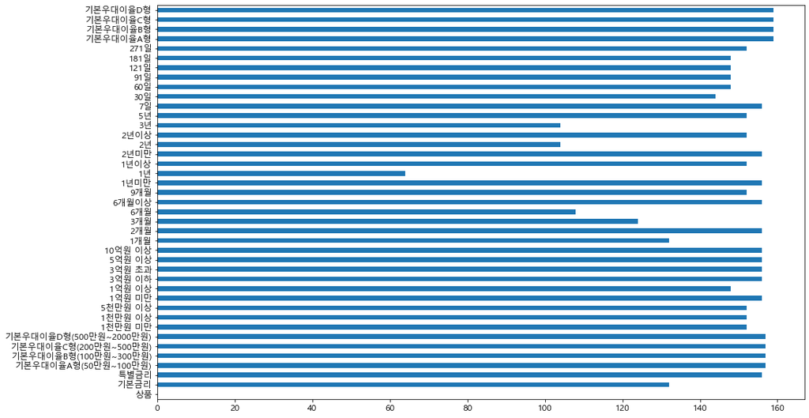

```python
plt.figure(figsize=(16,10))
df.isnull().sum().plot(kind='barh')
plt.show()
```

### ※ 예금금리 파일에서 결측치는 의미 없는 공란이지만 같은 행에 필요한 데이터가 있으니 0을 채운다.

```python
df.fillna(0, inplace=True)
df2.fillna(0, inplace=True)
df3.fillna(0, inplace=True)
df4.fillna(0, inplace=True)
df5.fillna(0, inplace=True)
df6.fillna(0, inplace=True)
```

## 데이터 시각화

[figure not shown]

```python
# 예금 금리가 1%도 넘지 않는 모습을 보여주며 최근에 다시 예금 금리가 많이 하락한 모습이다.

data = pd.pivot_table(df, values='담보콜금리전체', index='연도')
data.plot(kind='line',figsize=(10,5))
plt.legend(['1년 금리'])
plt.show()
```

```python
# 무담보콜금리전체 행과 2000~2020년 열 데이터만 가져오기
df2_mudambo=df2.loc[0,'2000':'2020']
```

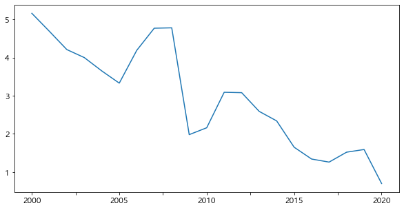

```python
df2_mudambo.plot(kind='line',figsize=(10,5))
```

### ★대출금리도 예금금리와 마찬가지로 하락하는 모습을 보인다.

```python
# 2007~2020년 전국 총 대출금 데이터 가져오기
df3_total=df3.loc[0,'2007':'2020']
```

```python
# df3_total은 list로 되어있다. 하지만 숫자들이 String이어서 바로 그래프로 만들 수가 없다.
# 803,724.1 처럼 반점과 온점이 섞여있어 타입변환도 불가능하다.
df3_total.unique()
```

```
array(['803,724.1', '917,110.1', '953,505.2', '987,148.1', '1,063,192.5',
       '1,099,781.8', '1,154,760.3', '1,250,103.3', '1,346,815.8',
       '1,424,149.2', '1,504,333.3', '1,600,280.5', '1,698,612.9',
       '1,893,716.2'], dtype=object)
```

```python
# 타입변환도 불가능하여 근삿값을 새로 list로 대입한다.
df3_total['2007':'2020']=[80,91,95,98,106,109,115,125,134,142,150,160,169,189]
```

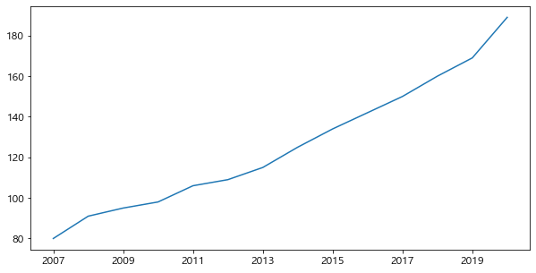

```python
df3_total.plot(kind='line',figsize=(10,5))
```

### ★매년 국민의 총 대출금은 증가하는 모습을 보여준다.

## ●결론(1): 금리가 줄어들면 대출의 부담이 줄어들어 은행에서 대출을 많이 한다는 결론이 나온다.

### 가설(1)

- 금리가 높을때는 임대인이 전세를 내어 전세금으로 자금조달을 받어 은행에 예금하든 재투자를 하든 돈을 벌 수 있었다. 하지만 금리가 낮아지면 임대인은 은행에서 대출하여 자금조달을 받고 그 자금으로 재투자를 하면 되는 것이다. 그리고 집은 월세로 내면 월세로 은행 대출이자를 채우고도 남는다.
- 그렇다면 이 가설에 따라 금리가 전세 매물이 줄어드는 원인일까?

### 전세 매물이 줄어드는 다른 이유도 있을까?

```python
# 2015~2021년 전국 총 월세가격 데이터 가져오기
df4_total=df4.loc[0,'2015. 06':'2021. 10']
```

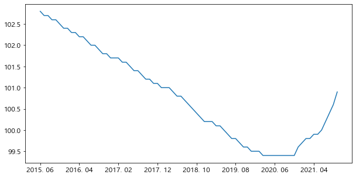

```python
df4_total.plot(kind='line',figsize=(10,5))
```

### ★월세 가격은 6년간 2% 정도 변화가 있었다.

```python
# 2006~2021년 전국 총 전세가격 데이터 가져오기
df5_total=df5.loc[0,'2015. 06':'2021. 10']
```

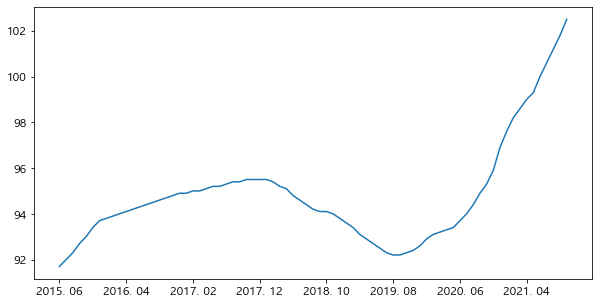

```python
df5_total.plot(kind='line',figsize=(10,5))
```

### ★전세 가격은 6년간 10% 정도 변화가 있었다. 월세에 비해 많이 상승한 모습을 보여준다.

## ●결론(2): 전세가격이 증가했다.

### 가설(2)

- 전세가격이 급격히 오르면 임차인은 급격히 오른 전세금을 내야하는 상황이된다.
- 임대인은 낮은 금리로 어차피 월세가 이득인 상황이고 임차인은 상승한 전세금을 견디지못한다.
- 임대인과 임차인이 전세를 월세나 반전세로 전환하는 같은의견을 공유하면서 전세 매물이 많이 사라진 것이 아닐까?

```python
# 2012~2019년 전체 주택유형 및 주거실태 데이터 가져오기 / 전세와 월세 비율
df6_total=df6.loc[2,'2012':'2019'] # 전세
df6_month=df6.loc[4,'2012':'2019'] # 월세
df6_ex=df6.loc[6,'2012':'2019']    # 기타 유형
```

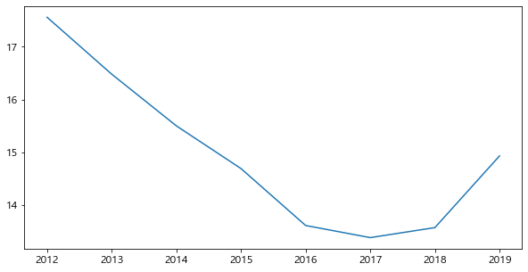

```python
# 연도별 전세 비율
df6_total.astype('float64').plot(kind='line',figsize=(10,5))
```

### ★ 지속적으로 전세 매물이 감소하다 최근에 소폭 상승한 모습이 보인다.

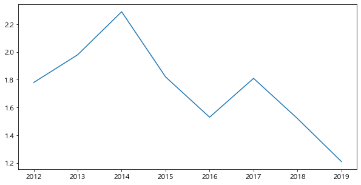

```python
# 연도별 월세 비율
df6_month.astype('float64').plot(kind='line',figsize=(10,5))
```

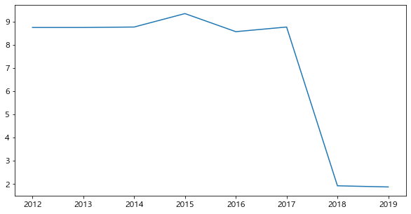

```python
# 연도별 기타 유형 비율
df6_ex.astype('float64').plot(kind='line',figsize=(10,5))
```

### ★ 기타 유형의 주거 형태가 최근들어 급격히 감소한 모습을 보인다.

## ●결론(3): 전세 매물이 지속적으로 감소하다 최근 증가 했다.

### 가설(3)

- 전세가 계속해서 줄어듬에 따라 기타유형의 주거유형을 정부에서 전세로 공급하고 있는 것 같다.

# ●최종결론: 전세가 줄어든 이유는 금리 영향은 있지만 원인이 금리 때문만은 아니다.

## 이유1: 금리는 여전히 하락세 이지만 최근에 전세가 증가했다.(결론1)

```
-하지만 기타 주택유형 이 전세로 전환되어 전세가 증가했을 가능성이 높다. (결론3)
```

## 이유2: 전세가격이 상승하면서 전세가 월세로 전환한 사례도 많을 것이다.(결론2)